# turtle_commands_C

## turtle_commands_C

#### Question

1. Consider the $L$-system (and angle) defined below:
   - Start: `A`
   - Rules:  
     `A > AA[-B][+B]B`  
     `B > B[-ABC][+ABC]`  
     `C > C[-CBA][+CBA]`
   - Number of recursions (number of iterations):
     - 4
   - Angle
     - 60°

   Please use [this L-system string generator](https://chadworley.github.io/Lsys_string_gen.html) along with [Turbo Turtle](https://scratch.mit.edu/projects/1225522722/editor/) to generate the pattern.

   With Turbo Turtle, you’ll want to “See Inside” to adjust the initial $x$, initial $y$, and `DISTANCE` variable to get the pattern centered and scaled. You’ll also want to turn on Turbo Mode (in the Edit drop-down menu).

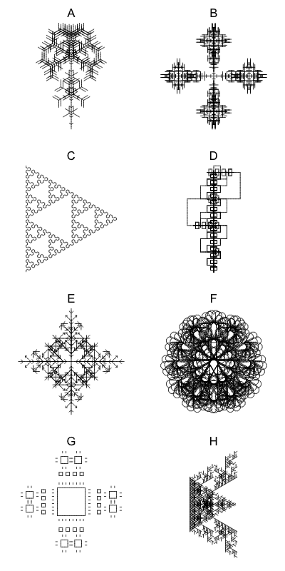

   1. A
   2. B
   3. C
   4. D
   5. E
   6. F
   7. G
   8. H

#### Question

2. Consider the $L$-system (and angle) defined below:
   - Start: `[A]+[A]+[A]+[A]+[A]+[A]`
   - Rules:  
     `A > AA[-B][+B]B`  
     `B > [-ABC][+ABC]`  
     `C > A[-CB][+CB]`
   - Number of recursions (number of iterations):
     - 4
   - Angle
     - 60°

   Please use [this L-system string generator](https://chadworley.github.io/Lsys_string_gen.html) along with [Turbo Turtle](https://scratch.mit.edu/projects/1225522722/editor/) to generate the pattern.

   With Turbo Turtle, you’ll want to “See Inside” to adjust the initial $x$, initial $y$, and `DISTANCE` variable to get the pattern centered and scaled. You’ll also want to turn on Turbo Mode (in the Edit drop-down menu).

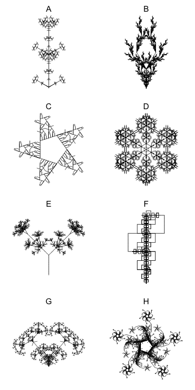

   1. A
   2. B
   3. C
   4. D
   5. E
   6. F
   7. G
   8. H

#### Question

3. Consider the $L$-system (and angle) defined below:
   - Start: `A++++XA`
   - Rules:  
     `A > AA[-B][+B]B`  
     `B > [---ABC][+++ABC]`  
     `C > A[-CB][+CB]`  
     `X > XX`
   - Number of recursions (number of iterations):
     - 5
   - Angle
     - 45°

   Please use [this L-system string generator](https://chadworley.github.io/Lsys_string_gen.html) along with [Turbo Turtle](https://scratch.mit.edu/projects/1225522722/editor/) to generate the pattern.

   With Turbo Turtle, you’ll want to “See Inside” to adjust the initial $x$, initial $y$, and `DISTANCE` variable to get the pattern centered and scaled. You’ll also want to turn on Turbo Mode (in the Edit drop-down menu).

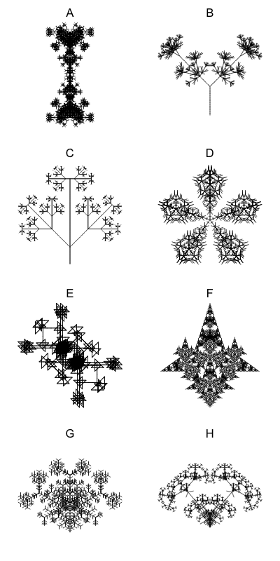

   1. A
   2. B
   3. C
   4. D
   5. E
   6. F
   7. G
   8. H